# Real GNP (Percentage change)

Sambit Ghosh

Subhajit Karmakar

2023-06-05

## Description

Here we have the data of GNP from **U.S. Bureau of Economic Analysis** and we will work with the percentage change in the GNP from quarter to quarter.

Data source: https://fred.stlouisfed.org/series/A001RO1Q156NBEA#0

```r
library(tidyverse)
library(fGarch)
library(glue)

df <- read.csv("C:/Users/sambi/Downloads/GNP data.csv")
glimpse(df)
```

```
## Rows: 301
## Columns: 2
## $ DATE            <chr> "1948-01-01", "1948-04-01", "1948-07-01", "1948-10-01"…
## $ A001RO1Q156NBEA <dbl> 2.7, 4.7, 5.5, 3.9, 0.9, -1.1, -0.7, -1.6, 3.7, 7.3, 1…
```

We see that, we have **301** data points in total and the types of the columns in the data are not in proper manner, for example the date is in `character` format. We need to modify that and visualize the data.

```r
colnames(df) <- c('Date', "Change")
df$Date <- as.Date(df$Date, format = '%Y-%m-%d')


glue('Starting date: {d1}',
     'Ending date: {d2}', .sep = "\n",
     d1 = min(df$Date), d2 = max(df$Date))
```

```
## Starting date: 1948-01-01
## Ending date: 2023-01-01
```

Thus we have data from $\small 1^{st}\ Quarter, 1948$ to $\small 1^{st}\ Quarter, 2023$.

## Visualization

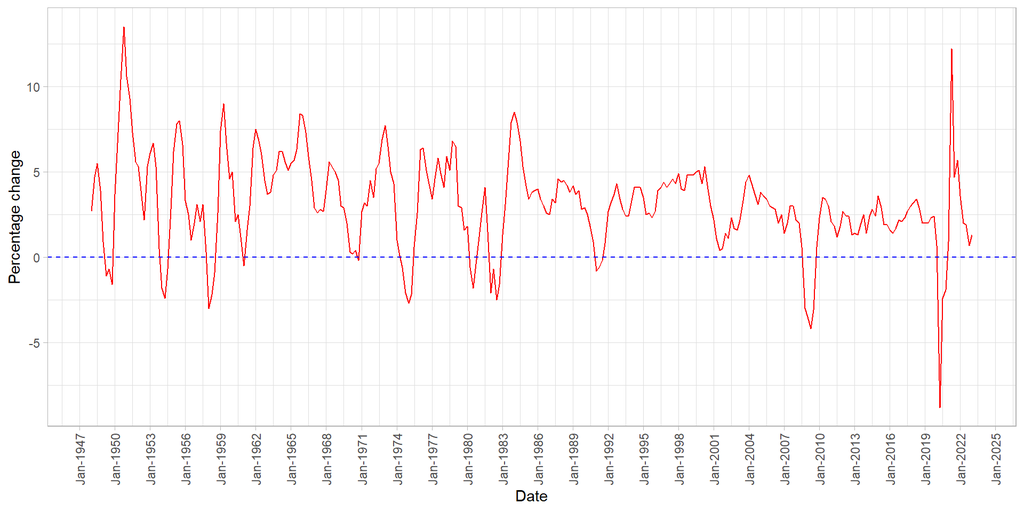

```r
df %>% ggplot(aes(x = Date, y = Change)) +
  geom_line(colour = 'red') + theme_light() +
  scale_x_date(date_labels = "%b-%Y",
               date_breaks = "3 years") +
  theme(axis.text.x = element_text(angle = 90,
                                   vjust = 0.5)) +
  geom_hline(yintercept = 0, colour = 'blue', lty = 2) +
  labs(y = "Percentage change")
```

**Note:** Since the data is in *percentage change* form, so it is already in *difference* form, so it is expected that no systematic pattern will be there in the data. Let $\small \{x_t\}$ be the amount of percentage change at $\small t^{th}$ quarter.

We will wish to fit a **AR** model to our data. The main task is to determine the order of Auto-Regressive model. Now let us look at the **ACF** and **PACF** of $\small x_t$.

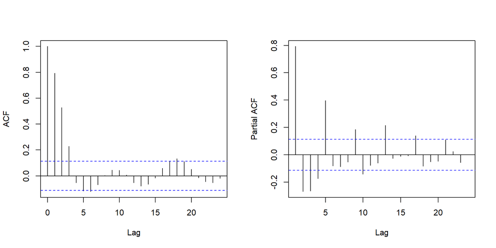

```r
par(mfrow = c(1,2))
acf(df$Change, main = '')
pacf(df$Change, main = '')
```

```r
arima(df$Change, order = c(13,0,0)) -> a1
a1
```

```
##
## Call:
## arima(x = df$Change, order = c(13, 0, 0))
##
## Coefficients:
##          ar1     ar2      ar3      ar4     ar5    ar6      ar7      ar8     ar9
##       1.0416  0.0448  -0.1141  -0.8874  0.8700  0.011  -0.0340  -0.7184  0.7662
## s.e.  0.0547  0.0789   0.0791   0.0803  0.0889  0.098   0.0981   0.1033  0.1023
##          ar10    ar11     ar12    ar13  intercept
##       -0.0750  0.0086  -0.4959  0.3628     3.0950
## s.e.   0.1029  0.1027   0.1050  0.0689     0.3146
##
## sigma^2 estimated as 1.469:  log likelihood = -488,  aic = 1006
```

**Observations:** $\small \sigma^2 = 1.469$ and $\small AIC = 1006$.

Now that we have fitted this **AR(13)** model, we will check for the residuals that if they can be considered as white noises. For this we will use **Ljung-Box** test, where the hypothesis to be tested is given by:

$$\small H_0: \rho_1 = \rho_2 = \cdots =
\rho_m = 0 \quad vs\quad H_1: Not\ H_0$$
$\small \rho_k$ being the auto-correlation at lag k.

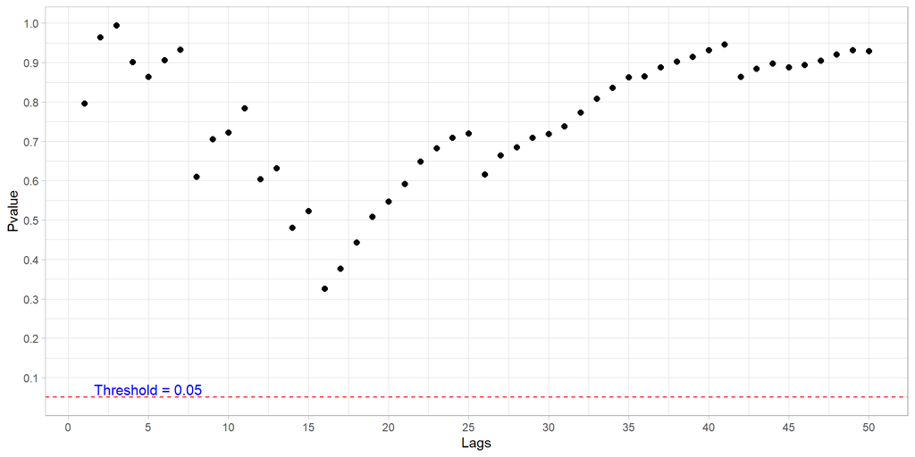

```r
# Function to plot the p-values:

p.func <- function(highest_lag, res){
  pval <- 0
  for(i in 1:highest_lag) (pval[i] =
                    Box.test(a1$residuals, lag = i,
                 type = "Ljung-Box")$p.value)

  data.frame('Lags' = 1:highest_lag, 'Pvalue' = pval) %>%
  ggplot(aes(x = Lags, y = Pvalue)) +
  geom_point(size = 2) + theme_light() +
  geom_hline(yintercept = 0.05,
               linetype = 2, colour = 'red') +
  scale_x_continuous(n.breaks = 10) +
  scale_y_continuous(n.breaks = 10) +
  annotate("text", x = 5, y = 0.07,
             label = "Threshold = 0.05",
             size = 4, colour = 'blue')
}

p.func(50, a1$residuals)
```

**Comment:** We can see that, all the p-values are much higher than 0.05, implies that the residuals can be considered as white noises, or we can say that, **AR(13)** is appropriate for our data.

But, one thing should be noted that the t-values (coefficients/standard error) obtained from the partial autocorrelation coefficients and the standard errors, many of them are very small, implies that those coefficients are not statistically significant, so inclusion of those lagged terms in our model is not necessary. In the next step, we omit them and re-fit an AR(13) model.

From the table of coefficients, we see that, *lag-2*, *lag-3*, *lag-6*,*lag-7*,*lag-10*,*lag-11* are not statistically significant.

```r
arima(df$Change, order = c(13,0,0),
      fixed = c(NA,0,0,NA,NA,0,0,NA,NA,0,0,NA,NA,NA)) ->a2
a2
```

```
##
## Call:
## arima(x = df$Change, order = c(13, 0, 0), fixed = c(NA, 0, 0, NA, NA, 0, 0,
##     NA, NA, 0, 0, NA, NA, NA))
##
## Coefficients:
##          ar1  ar2  ar3      ar4     ar5  ar6  ar7      ar8     ar9  ar10  ar11
##       1.0292    0    0  -0.9450  0.8607    0    0  -0.7319  0.7180     0     0
## s.e.  0.0306    0    0   0.0641  0.0721    0    0   0.0842  0.0836     0     0
##          ar12    ar13  intercept
##       -0.5338  0.3780     3.0956
## s.e.   0.0751  0.0673     0.3099
##
## sigma^2 estimated as 1.489:  log likelihood = -489.99,  aic = 997.98
```

**Observations:**

- $\small \sigma^2 = 1.489$ and $\small AIC = 997.98$
- All the coefficients are statistically significant.
- AIC value is less than the earlier one and variance being almost the same as previous.
- The number of terms in the model has also decreased.

## Final model

The final model we consider is as follows: $\scriptsize\mathbf{x_t = 3.0956 + 1.0292x_{t-1} - 0.945x_{t-4} + 0.8607x_{t-5} - 0.7319x_{t-8} + 0.718x_{t-9} - 0.5338x_{t-12} + 0.378x_{t-13}}$

We again perform **Ljung-Box** test to verify whether the residuals from this model can be considered as white noises or not. Also, we will plot the ACFs to see if the residuals are correlated.

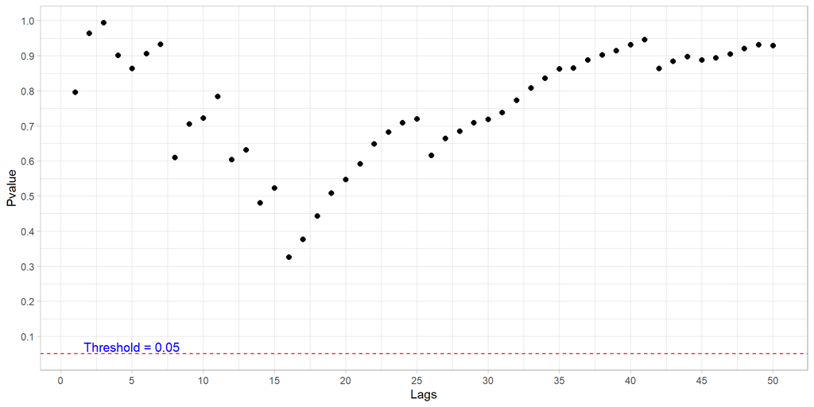

```r
p.func(50, a2$residuals)
```

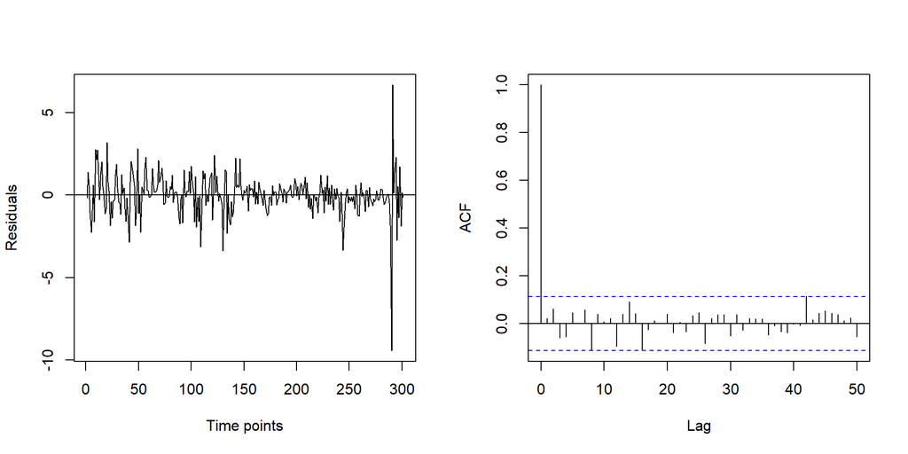

```r
par(mfrow = c(1,2))
plot(a2$residuals, ylab = 'Residuals',
     xlab = 'Time points')
abline(h= 0)
acf(a2$residuals, main = '', lag.max = 50)
```

**Comment:** From the above plots, we can summarize our findings in this manner: the residuals are fluctuating almost randomly above and below 0, and from the ACF plot, all the autocorrelation values are within the confidence interval, implies that the auto-correlations are not statistically significant i.e. the residuals are uncorrelated. Also, all the p-values obtained from Ljung-Box test are much more higher than 0.05 i.e. we fail to reject the null hypothesis that all the auto-correlations are statistically insignificant.

## Volatility model

In spite of none of the ACF values of residuals of the fitted model are significant, there may exist dependency among the residuals as can be detected faintly by the varying ranges of residual plot at different time points, indicating a slight volatility in the model.

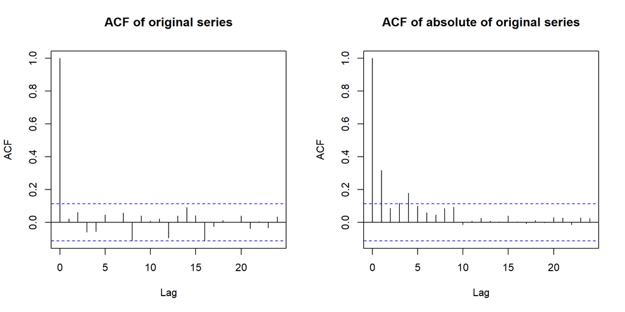

```r
par(mfrow = c(1,2))
acf(a2$residuals, main = 'ACF of original series')
acf(abs(a2$residuals), main = 'ACF of absolute of original series')
```

**Comment:** From the graph on the right panel, it is clear that there exists serial correlation upto a maximum of lag 4.

We further test for ARCH effect now.

#### **Test 1**

```r
Box.test(a2$residuals, type = 'Ljung-Box', lag = 4)
```

```
##
##  Box-Ljung test
##
## data:  a2$residuals
## X-squared = 3.3273, df = 4, p-value = 0.5046
```

```r
Box.test(abs(a2$residuals), type = 'Ljung-Box', lag = 4)
```

```
##
##  Box-Ljung test
##
## data:  abs(a2$residuals)
## X-squared = 46.995, df = 4, p-value = 1.529e-09
```

#### **Test 2**

*This test is applied to check for linear relationship between the past squared residuals.*

```r
# Fitting multiple linear regression:
f <- function(x, m){

  n <- length(x); n
  M <- as.data.frame(matrix(ncol = m+1, nrow = n-m,
                            dimnames = list(1:(n-m),
                                            c('y',paste0('x',1:m)))))

  for(i in (m+1):1) (M[,i] <- (x[i:(n-m-1+i)])^2)

  cname <- names(M); cname

  reformulate(cname[2:(m+1)], response = 'y') -> f
  f %>% lm(data = M) %>% summary() -> s
  pf(s$fstatistic, m, n-2*m-1, lower.tail = F)[[1]] %>%
    return()
}


glue('p-value of the regression: {p}',
           p = f(a2$residuals, 4))
```

```
## p-value of the regression: 9.47129115345557e-12
```

**Comment:** Clearly there exists a strong case for the presence of ARCH effect in the shock values.

## Model fitting

```r
arch4 <- garchFit(~1 + garch(4,0), data = a2$residuals, trace = F,
                  include.mean = F)
summary(arch4)
```

```
##
## Title:
##  GARCH Modelling
##
## Call:
##  garchFit(formula = ~1 + garch(4, 0), data = a2$residuals, include.mean = F,
##     trace = F)
##
## Mean and Variance Equation:
##  data ~ 1 + garch(4, 0)
## <environment: 0x0000015adb32e400>
##  [data = a2$residuals]
##
## Conditional Distribution:
##  norm
##
## Coefficient(s):
##    omega    alpha1    alpha2    alpha3    alpha4
## 0.412074  0.720027  0.122635  0.075402  0.071965
##
## Std. Errors:
##  based on Hessian
##
## Error Analysis:
##         Estimate  Std. Error  t value Pr(>|t|)
## omega    0.41207     0.07932    5.195 2.05e-07 ***
## alpha1   0.72003     0.14512    4.962 6.99e-07 ***
## alpha2   0.12263     0.07555    1.623    0.105
## alpha3   0.07540     0.05250    1.436    0.151
## alpha4   0.07197     0.05904    1.219    0.223
## ---
## Signif. codes:  0 '***' 0.001 '**' 0.01 '*' 0.05 '.' 0.1 ' ' 1
##
## Log Likelihood:
##  -443.4203    normalized:  -1.473157
##
## Description:
##  Thu Oct  5 23:05:11 2023 by user: sambi
##
##
## Standardised Residuals Tests:
##                                 Statistic p-Value
##  Jarque-Bera Test   R    Chi^2  223.3108  0
##  Shapiro-Wilk Test  R    W      0.9488748 9.921129e-09
##  Ljung-Box Test     R    Q(10)  19.21792  0.03758046
##  Ljung-Box Test     R    Q(15)  33.9273   0.003486304
##  Ljung-Box Test     R    Q(20)  40.74993  0.004010545
##  Ljung-Box Test     R^2  Q(10)  2.155542  0.995003
##  Ljung-Box Test     R^2  Q(15)  2.998651  0.9995989
##  Ljung-Box Test     R^2  Q(20)  3.222248  0.9999924
##  LM Arch Test       R    TR^2   3.172805  0.9941961
##
## Information Criterion Statistics:
##      AIC      BIC      SIC     HQIC
## 2.979537 3.041117 2.978997 3.004179
```

The fitted ARCH model is given by:
$$\sigma^2_t = 0.41207 + 0.72003\cdot a_{t-1} + 0.12263\cdot a_{t-2} +
0.0754\cdot a_{t-3} + 0.07197\cdot a_{t-4}$$

From the above summary table, it is clear that $\small \alpha_2,\alpha_3,\alpha_4$ are statistically insignificant, so it makes sense to update the model fitted.

We also note that the ACF of the absolute residuals at lags 2 and 3 were also not statistically significant.

```r
arch1 <- garchFit(~1 + garch(1,0), data = a2$residuals, trace = F,
                  include.mean = F)
summary(arch1)
```

```
##
## Title:
##  GARCH Modelling
##
## Call:
##  garchFit(formula = ~1 + garch(1, 0), data = a2$residuals, include.mean = F,
##     trace = F)
##
## Mean and Variance Equation:
##  data ~ 1 + garch(1, 0)
## <environment: 0x0000015ad3df47c0>
##  [data = a2$residuals]
##
## Conditional Distribution:
##  norm
##
## Coefficient(s):
##   omega   alpha1
## 0.72497  0.65367
##
## Std. Errors:
##  based on Hessian
##
## Error Analysis:
##         Estimate  Std. Error  t value Pr(>|t|)
## omega    0.72497     0.08417    8.613  < 2e-16 ***
## alpha1   0.65367     0.14200    4.603 4.16e-06 ***
## ---
## Signif. codes:  0 '***' 0.001 '**' 0.01 '*' 0.05 '.' 0.1 ' ' 1
##
## Log Likelihood:
##  -451.7668    normalized:  -1.500886
##
## Description:
##  Thu Oct  5 23:05:11 2023 by user: sambi
##
##
## Standardised Residuals Tests:
##                                 Statistic p-Value
##  Jarque-Bera Test   R    Chi^2  196.6033  0
##  Shapiro-Wilk Test  R    W      0.9482534 8.417182e-09
##  Ljung-Box Test     R    Q(10)  16.97909  0.07482789
##  Ljung-Box Test     R    Q(15)  29.56035  0.0136094
##  Ljung-Box Test     R    Q(20)  37.2728   0.0108509
##  Ljung-Box Test     R^2  Q(10)  4.100174  0.9427148
##  Ljung-Box Test     R^2  Q(15)  4.885561  0.9930518
##  Ljung-Box Test     R^2  Q(20)  5.27229   0.9995824
##  LM Arch Test       R    TR^2   4.052082  0.9824781
##
## Information Criterion Statistics:
##      AIC      BIC      SIC     HQIC
## 3.015062 3.039693 3.014974 3.024918
```

The final fitted ARCH model is given by:
$$\sigma^2_t = 0.72497 + 0.65367\cdot a_{t-1}$$

## Forcasting

Now, we forecast for 2023 Q2 seasonally adjusted percentage change of GNP of US.

The one-step ahead AR forecast is given by:

```r
predict(a2)
```

```
## $pred
## Time Series:
## Start = 302
## End = 302
## Frequency = 1
## [1] -0.07857324
##
## $se
## Time Series:
## Start = 302
## End = 302
## Frequency = 1
## [1] 1.220117
```

```r
u_302 <- predict(a2)$pred[1]
```

The volatility for the past observed GNPs are given by:

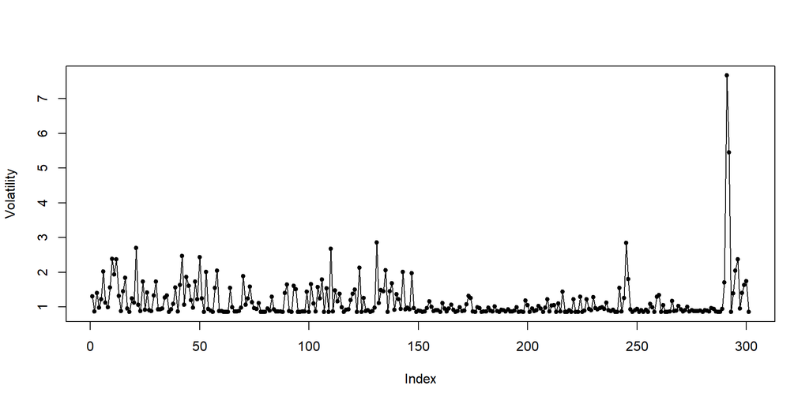

```r
plot(volatility(arch1), type = 'o', pch = 20,
     ylab = 'Volatility')
```

Now, we predict the volatility for the one-step ahead forecasted value.

```r
sigma_sq_302 <- 0.72497 + 0.65367*(a2$residuals[301])^2
sqrt(sigma_sq_302)
```

```
## [1] 0.8579916
```